```python
%matplotlib inline
from datetime import datetime, date  # working with date and time
import matplotlib.pyplot as plt      # graphing
import numpy as np                   # math
import os                            # useful for handling filenames etc.
import pandas as pd                  # manipulating data
from scipy.stats import pearsonr     # calculates the Pearson correlation coefficient and p-value
import seaborn as sns                # makes matplotlib beautiful
sns.set_style('darkgrid')
import weather_station_utils as wsu  # helper functions for WeatherUnderground data

import matplotlib as mpl             # control formatting
mpl.rcParams['axes.titlesize'] = 16
mpl.rcParams['axes.titleweight'] = 'semibold'

# interactive graphs
from bokeh.io import output_notebook, show, push_notebook
from bokeh.plotting import figure
from bokeh.layouts import row, column
from bokeh.models import DatetimeTickFormatter
output_notebook()
```

# Pinewood High School

In this notebook, we explore the data collected at [Pinewood High School](https://radwatch.berkeley.edu/dosenet/schools/pinewood). We do not expect to see much effect of the recent fire, since we saw little impact even in Berkeley. We will verify this hypothesis in this notebook.

[figure not shown]

We are using data collected starting on June 29, 2018, to maintain uniformity with the Etcheverry Hall fire analysis notebook (`finished_notebooks/fire_and_smoke.html`) and ending on July 10, 2018. We are binning/averaging over 3-hour windows.

```python
INTERVAL = 10800  # 3 hours
DATA_DIR = 'binned_data_10_days'
LOCATION = 'pine'  # Pinewood High School
dosenet_data = wsu.get_all_binned(interval=INTERVAL, data_dir=DATA_DIR, location=LOCATION)
dosenet_data
```

|  | unix_time | co2 | radiation | pgradiation | humidity | temperature | pressure | pm1 | pm25 | pm10 |
| --- | --- | --- | --- | --- | --- | --- | --- | --- | --- | --- |
| 0 | 1530255601 | 465.761111 | 1193.972222 | 2.272222 | 65.406389 | 16.980278 | 1008.314444 | 2.245556 | 4.628056 | 6.363611 |
| 1 | 1530266401 | 484.295000 | 1211.777778 | 2.305556 | 70.221667 | 15.195833 | 1008.490278 | 1.803056 | 3.916944 | 5.451111 |
| 2 | 1530277201 | 487.493889 | 1240.294444 | 2.033333 | 63.835833 | 18.486111 | 1008.793056 | 3.178611 | 5.371111 | 7.340833 |
| 3 | 1530288001 | 479.014722 | 1238.905556 | 2.105556 | 49.308611 | 23.813889 | 1008.729722 | 3.413611 | 5.592778 | 7.482778 |
| 4 | 1530298801 | 544.873889 | 1224.305556 | 2.544444 | 33.967500 | 31.933333 | 1007.770556 | 3.633056 | 5.697500 | 7.271944 |
| 5 | 1530309601 | 543.575000 | 1200.005556 | 3.455556 | 30.576111 | 32.908333 | 1006.498056 | 2.900000 | 4.792500 | 6.166667 |
| 6 | 1530320401 | 501.243889 | 1196.044444 | 2.672222 | 33.067500 | 29.483611 | 1005.933056 | 1.774167 | 3.306667 | 4.392500 |
| 7 | 1530331201 | 504.337222 | 1186.650000 | 2.105556 | 54.357222 | 22.825000 | 1006.604444 | 3.721667 | 5.835833 | 7.887500 |
| 8 | 1530342001 | 512.598333 | 1215.133333 | 2.205556 | 66.570833 | 19.549444 | 1006.307778 | 3.773889 | 5.949167 | 8.117222 |
| 9 | 1530352801 | 524.348056 | 1227.888889 | 2.061111 | 72.352222 | 17.447222 | 1006.545000 | 3.441111 | 5.625000 | 7.610556 |
| 10 | 1530363601 | 542.886389 | 1242.305556 | 2.105556 | 63.915556 | 21.132222 | 1007.355278 | 3.863889 | 6.351111 | 8.741111 |
| 11 | 1530374401 | 539.146389 | 1236.138889 | 1.900000 | 42.790556 | 28.307222 | 1007.430278 | 3.099722 | 5.112222 | 6.758611 |
| 12 | 1530385201 | 613.327500 | 1228.677778 | 2.509091 | 29.931667 | 35.308611 | 1006.834722 | 3.597778 | 5.697222 | 7.213611 |
| 13 | 1530396001 | 539.061944 | 1207.744444 | 3.000000 | 33.182500 | 33.653056 | 1006.401667 | 3.861944 | 6.106944 | 7.625556 |
| 14 | 1530406801 | 465.373611 | 1192.843243 | 2.094444 | 45.750278 | 27.739444 | 1007.253611 | 4.043333 | 6.564167 | 8.570833 |
| 15 | 1530417601 | 468.617500 | 1195.900000 | 2.311111 | 59.645556 | 22.955833 | 1008.161111 | 7.272778 | 10.550278 | 13.215556 |
| 16 | 1530428401 | 442.710556 | 1192.377778 | 2.322222 | 70.090556 | 19.956667 | 1008.454167 | 3.172778 | 5.290278 | 6.671389 |
| 17 | 1530439201 | 456.248056 | 1202.388889 | 2.133333 | 74.066389 | 19.062222 | 1008.866944 | 2.240833 | 4.452222 | 5.674444 |
| 18 | 1530450001 | 460.411389 | 1197.566667 | 2.183333 | 68.101389 | 21.353333 | 1009.963889 | 4.679167 | 7.247222 | 8.680278 |
| 19 | 1530460801 | 451.022222 | 1203.005556 | 2.338889 | 58.870556 | 24.410000 | 1010.089444 | 3.788333 | 5.929444 | 6.878333 |
| 20 | 1530471601 | 471.921667 | 1206.283333 | 2.116667 | 49.717778 | 27.630000 | 1010.109167 | 3.815833 | 5.840833 | 6.736389 |
| 21 | 1530482401 | 439.710303 | 1199.657143 | 1.951515 | 47.111429 | 27.750286 | 1009.823714 | 0.925714 | 2.179714 | 2.693429 |
| 22 | 1530493201 | 420.162778 | 1198.105556 | 2.150000 | 53.660278 | 24.836111 | 1009.840000 | 0.955556 | 2.000000 | 2.461111 |
| 23 | 1530504001 | 421.778333 | 1183.111111 | 2.105556 | 67.813611 | 21.036111 | 1010.341111 | 0.794167 | 1.840278 | 2.376944 |
| 24 | 1530514801 | 419.647778 | 1180.194444 | 2.133333 | 72.023611 | 19.943889 | 1009.763889 | 1.551389 | 3.168056 | 3.948056 |
| 25 | 1530525601 | 427.036944 | 1195.300000 | 2.194444 | 71.818056 | 19.507500 | 1009.335278 | 4.366389 | 6.773611 | 7.983611 |
| 26 | 1530536401 | 423.674167 | 1211.702703 | 2.061111 | 70.222500 | 19.903889 | 1009.851667 | 3.620270 | 5.720000 | 6.813784 |
| 27 | 1530547201 | 423.521944 | 1194.838889 | 2.138889 | 61.007222 | 22.610556 | 1010.079167 | 4.000278 | 6.299167 | 7.502778 |
| 28 | 1530558001 | 425.490833 | 1201.855556 | 2.161111 | 51.649444 | 25.903333 | 1009.557778 | 3.201389 | 5.198056 | 6.200278 |
| 29 | 1530568801 | 428.656667 | 1196.205556 | 2.288889 | 48.904444 | 26.601667 | 1008.292500 | 1.065000 | 2.548056 | 3.146944 |
| ... | ... | ... | ... | ... | ... | ... | ... | ... | ... | ... |
| 71 | 1531022401 | 442.068056 | 1183.150000 | 2.238889 | NaN | NaN | NaN | 3.039444 | 5.069444 | 6.346389 |
| 72 | 1531033201 | 441.635000 | 1181.611111 | 1.955556 | NaN | NaN | NaN | 1.685833 | 3.758889 | 5.365000 |
| 73 | 1531044001 | 446.426944 | 1201.627778 | 2.011111 | NaN | NaN | NaN | 1.842778 | 3.950556 | 5.613611 |
| 74 | 1531054801 | 451.380833 | 1199.150000 | 2.205556 | NaN | NaN | NaN | 2.092500 | 4.511111 | 6.379722 |
| 75 | 1531065601 | 444.702222 | 1186.583333 | 2.027778 | NaN | NaN | NaN | 2.070000 | 4.349722 | 6.059444 |
| 76 | 1531076401 | 470.127222 | 1187.233333 | 2.133333 | NaN | NaN | NaN | 1.867778 | 3.923333 | 5.313333 |
| 77 | 1531087201 | 479.141818 | 1182.205714 | 3.606061 | 26.103478 | 33.115217 | 1010.317826 | 0.772286 | 1.927143 | 2.568857 |
| 78 | 1531098001 | 417.714444 | 1175.377778 | 2.805556 | 17.225278 | 30.393333 | 1010.386944 | 0.060833 | 0.085833 | 0.091389 |
| 79 | 1531108801 | 417.732778 | 1186.394444 | 2.088889 | 41.488056 | 23.579444 | 1011.795833 | 0.001389 | 0.533056 | 0.813889 |
| 80 | 1531119601 | 420.202778 | 1199.366667 | 2.016667 | 53.564118 | 20.301765 | 1012.183529 | 0.184167 | 1.143611 | 1.877222 |
| 81 | 1531130401 | 422.945278 | 1193.944444 | 2.233333 | NaN | NaN | NaN | 0.871944 | 2.035278 | 2.948333 |
| 82 | 1531141201 | 428.472778 | 1200.150000 | 2.105556 | NaN | NaN | NaN | 1.136667 | 2.825833 | 3.956667 |
| 83 | 1531152001 | 497.774722 | 1176.377778 | 2.205556 | NaN | NaN | NaN | 1.122222 | 2.786389 | 3.757222 |
| 84 | 1531162801 | 578.352432 | 1182.927778 | 3.545946 | NaN | NaN | NaN | 2.239722 | 3.872222 | 4.941389 |
| 85 | 1531173601 | 582.406842 | 1176.405556 | 3.989655 | 53.064286 | 25.179048 | 1006.491905 | 0.212456 | 0.582105 | 0.752807 |
| 86 | 1531184401 | 493.478611 | 1174.122222 | 3.721739 | 51.117500 | 25.094444 | 1005.914167 | 0.014306 | 0.106806 | 0.150694 |
| 87 | 1531195201 | 490.913151 | 1192.811111 | 1.769863 | 51.365833 | 24.788056 | 1006.354444 | 0.000000 | 0.019722 | 0.022500 |
| 88 | 1531206001 | 493.406712 | 1208.297297 | 1.761111 | 52.346486 | 24.475135 | 1006.017838 | 0.175616 | 0.621370 | 0.957260 |
| 89 | 1531216801 | 499.263333 | 1196.866667 | 1.700000 | 53.222500 | 24.381389 | 1005.489722 | 0.491667 | 1.144167 | 1.649583 |
| 90 | 1531227601 | 497.840278 | 1198.983333 | 1.825000 | 54.549444 | 24.222222 | 1006.134444 | 0.533611 | 1.502500 | 2.154167 |
| 91 | 1531238401 | 568.477500 | 1182.138889 | 1.638889 | 56.006389 | 24.587222 | 1006.458889 | 0.511944 | 1.506528 | 2.115417 |
| 92 | 1531249201 | 586.553889 | 1172.305556 | 2.925000 | 53.349167 | 25.123889 | 1006.001389 | 0.034028 | 0.399861 | 0.544028 |
| 93 | 1531260001 | 517.852174 | 1165.163636 | 5.233333 | 52.593636 | 25.490000 | 1004.929091 | 0.000000 | 0.005417 | 0.007917 |
| 94 | 1531270801 | NaN | NaN | NaN | NaN | NaN | NaN | NaN | NaN | NaN |
| 95 | 1531281601 | NaN | NaN | NaN | NaN | NaN | NaN | NaN | NaN | NaN |
| 96 | 1531292401 | NaN | NaN | NaN | NaN | NaN | NaN | NaN | NaN | NaN |
| 97 | 1531303201 | NaN | NaN | NaN | NaN | NaN | NaN | NaN | NaN | NaN |
| 98 | 1531314001 | NaN | NaN | NaN | NaN | NaN | NaN | NaN | NaN | NaN |
| 99 | 1531324801 | NaN | NaN | NaN | NaN | NaN | NaN | NaN | NaN | NaN |
| 100 | 1531335601 | NaN | NaN | NaN | NaN | NaN | NaN | NaN | NaN | NaN |

101 rows × 10 columns

Clearly, there are some gaps in our data, especially from the weather sensor (there are `NaN`s in the `humidity`, `temperature` and `pressure` columns). Let's remove those entries from the DataFrame.

```python
clean_dosenet_data = dosenet_data.dropna(axis=0, how='any')
clean_dosenet_data
```

|  | unix_time | co2 | radiation | pgradiation | humidity | temperature | pressure | pm1 | pm25 | pm10 |
| --- | --- | --- | --- | --- | --- | --- | --- | --- | --- | --- |
| 0 | 1530255601 | 465.761111 | 1193.972222 | 2.272222 | 65.406389 | 16.980278 | 1008.314444 | 2.245556 | 4.628056 | 6.363611 |
| 1 | 1530266401 | 484.295000 | 1211.777778 | 2.305556 | 70.221667 | 15.195833 | 1008.490278 | 1.803056 | 3.916944 | 5.451111 |
| 2 | 1530277201 | 487.493889 | 1240.294444 | 2.033333 | 63.835833 | 18.486111 | 1008.793056 | 3.178611 | 5.371111 | 7.340833 |
| 3 | 1530288001 | 479.014722 | 1238.905556 | 2.105556 | 49.308611 | 23.813889 | 1008.729722 | 3.413611 | 5.592778 | 7.482778 |
| 4 | 1530298801 | 544.873889 | 1224.305556 | 2.544444 | 33.967500 | 31.933333 | 1007.770556 | 3.633056 | 5.697500 | 7.271944 |
| 5 | 1530309601 | 543.575000 | 1200.005556 | 3.455556 | 30.576111 | 32.908333 | 1006.498056 | 2.900000 | 4.792500 | 6.166667 |
| 6 | 1530320401 | 501.243889 | 1196.044444 | 2.672222 | 33.067500 | 29.483611 | 1005.933056 | 1.774167 | 3.306667 | 4.392500 |
| 7 | 1530331201 | 504.337222 | 1186.650000 | 2.105556 | 54.357222 | 22.825000 | 1006.604444 | 3.721667 | 5.835833 | 7.887500 |
| 8 | 1530342001 | 512.598333 | 1215.133333 | 2.205556 | 66.570833 | 19.549444 | 1006.307778 | 3.773889 | 5.949167 | 8.117222 |
| 9 | 1530352801 | 524.348056 | 1227.888889 | 2.061111 | 72.352222 | 17.447222 | 1006.545000 | 3.441111 | 5.625000 | 7.610556 |
| 10 | 1530363601 | 542.886389 | 1242.305556 | 2.105556 | 63.915556 | 21.132222 | 1007.355278 | 3.863889 | 6.351111 | 8.741111 |
| 11 | 1530374401 | 539.146389 | 1236.138889 | 1.900000 | 42.790556 | 28.307222 | 1007.430278 | 3.099722 | 5.112222 | 6.758611 |
| 12 | 1530385201 | 613.327500 | 1228.677778 | 2.509091 | 29.931667 | 35.308611 | 1006.834722 | 3.597778 | 5.697222 | 7.213611 |
| 13 | 1530396001 | 539.061944 | 1207.744444 | 3.000000 | 33.182500 | 33.653056 | 1006.401667 | 3.861944 | 6.106944 | 7.625556 |
| 14 | 1530406801 | 465.373611 | 1192.843243 | 2.094444 | 45.750278 | 27.739444 | 1007.253611 | 4.043333 | 6.564167 | 8.570833 |
| 15 | 1530417601 | 468.617500 | 1195.900000 | 2.311111 | 59.645556 | 22.955833 | 1008.161111 | 7.272778 | 10.550278 | 13.215556 |
| 16 | 1530428401 | 442.710556 | 1192.377778 | 2.322222 | 70.090556 | 19.956667 | 1008.454167 | 3.172778 | 5.290278 | 6.671389 |
| 17 | 1530439201 | 456.248056 | 1202.388889 | 2.133333 | 74.066389 | 19.062222 | 1008.866944 | 2.240833 | 4.452222 | 5.674444 |
| 18 | 1530450001 | 460.411389 | 1197.566667 | 2.183333 | 68.101389 | 21.353333 | 1009.963889 | 4.679167 | 7.247222 | 8.680278 |
| 19 | 1530460801 | 451.022222 | 1203.005556 | 2.338889 | 58.870556 | 24.410000 | 1010.089444 | 3.788333 | 5.929444 | 6.878333 |
| 20 | 1530471601 | 471.921667 | 1206.283333 | 2.116667 | 49.717778 | 27.630000 | 1010.109167 | 3.815833 | 5.840833 | 6.736389 |
| 21 | 1530482401 | 439.710303 | 1199.657143 | 1.951515 | 47.111429 | 27.750286 | 1009.823714 | 0.925714 | 2.179714 | 2.693429 |
| 22 | 1530493201 | 420.162778 | 1198.105556 | 2.150000 | 53.660278 | 24.836111 | 1009.840000 | 0.955556 | 2.000000 | 2.461111 |
| 23 | 1530504001 | 421.778333 | 1183.111111 | 2.105556 | 67.813611 | 21.036111 | 1010.341111 | 0.794167 | 1.840278 | 2.376944 |
| 24 | 1530514801 | 419.647778 | 1180.194444 | 2.133333 | 72.023611 | 19.943889 | 1009.763889 | 1.551389 | 3.168056 | 3.948056 |
| 25 | 1530525601 | 427.036944 | 1195.300000 | 2.194444 | 71.818056 | 19.507500 | 1009.335278 | 4.366389 | 6.773611 | 7.983611 |
| 26 | 1530536401 | 423.674167 | 1211.702703 | 2.061111 | 70.222500 | 19.903889 | 1009.851667 | 3.620270 | 5.720000 | 6.813784 |
| 27 | 1530547201 | 423.521944 | 1194.838889 | 2.138889 | 61.007222 | 22.610556 | 1010.079167 | 4.000278 | 6.299167 | 7.502778 |
| 28 | 1530558001 | 425.490833 | 1201.855556 | 2.161111 | 51.649444 | 25.903333 | 1009.557778 | 3.201389 | 5.198056 | 6.200278 |
| 29 | 1530568801 | 428.656667 | 1196.205556 | 2.288889 | 48.904444 | 26.601667 | 1008.292500 | 1.065000 | 2.548056 | 3.146944 |
| ... | ... | ... | ... | ... | ... | ... | ... | ... | ... | ... |
| 36 | 1530644401 | 435.226667 | 1224.059459 | 2.194444 | 40.202778 | 28.373611 | 1006.366667 | 0.504167 | 1.446944 | 1.996944 |
| 37 | 1530655201 | 467.129167 | 1203.561111 | 2.094444 | 37.132500 | 29.996111 | 1005.567222 | 2.383611 | 4.419722 | 6.018611 |
| 38 | 1530666001 | 459.885000 | 1199.405556 | 2.222222 | 45.668611 | 26.340000 | 1005.768611 | 3.804722 | 6.139722 | 8.360556 |
| 39 | 1530676801 | 442.218889 | 1209.766667 | 1.977778 | 58.239722 | 20.857500 | 1007.130556 | 2.186389 | 4.388889 | 6.114444 |
| 40 | 1530687601 | 440.269730 | 1233.261111 | 2.145946 | 62.991622 | 17.431081 | 1007.506216 | 1.129167 | 2.795556 | 3.835278 |
| 41 | 1530698401 | 445.216944 | 1250.005405 | 2.188889 | 70.525556 | 15.498889 | 1008.061667 | 4.836757 | 7.260000 | 9.064865 |
| 42 | 1530709201 | 451.235405 | 1234.116667 | 2.266667 | 64.655278 | 17.989722 | 1009.858333 | 4.211944 | 6.622778 | 8.311667 |
| 43 | 1530720001 | 424.803889 | 1211.450000 | 2.133333 | 51.995278 | 21.963611 | 1010.769167 | 4.186389 | 6.637222 | 8.018889 |
| 44 | 1530730801 | 436.175833 | 1199.344444 | 2.133333 | 40.070833 | 27.105278 | 1010.689444 | 2.887568 | 4.468108 | 5.302703 |
| 45 | 1530741601 | 451.357778 | 1196.000000 | 2.172222 | 37.563333 | 28.807778 | 1009.677222 | 1.552778 | 2.982778 | 3.663056 |
| 46 | 1530752401 | 431.864722 | 1203.611111 | 2.027778 | 47.392222 | 24.368889 | 1009.953611 | 0.847778 | 1.934444 | 2.646944 |
| 47 | 1530763201 | 438.685556 | 1182.688889 | 2.044444 | 65.180833 | 20.263056 | 1012.234722 | 4.946111 | 7.501111 | 9.034722 |
| 48 | 1530774001 | 442.430541 | 1173.172222 | 2.081081 | 71.348378 | 18.582162 | 1013.181081 | 10.863333 | 14.842778 | 17.655556 |
| 49 | 1530784801 | 446.497500 | 1177.883333 | 2.005556 | 73.287222 | 18.100000 | 1013.668611 | 8.122222 | 11.423333 | 13.723333 |
| 50 | 1530795601 | 448.290000 | 1175.055556 | 1.883333 | 71.701389 | 18.391111 | 1015.115833 | 9.037500 | 12.760000 | 15.423056 |
| 51 | 1530806401 | 467.378611 | 1185.094444 | 2.022222 | 58.292778 | 22.538056 | 1015.422222 | 11.610556 | 15.777778 | 18.542778 |
| 52 | 1530817201 | 486.158611 | 1180.377778 | 2.266667 | 46.128750 | 27.325000 | 1015.438750 | 5.506111 | 8.058333 | 9.408333 |
| 77 | 1531087201 | 479.141818 | 1182.205714 | 3.606061 | 26.103478 | 33.115217 | 1010.317826 | 0.772286 | 1.927143 | 2.568857 |
| 78 | 1531098001 | 417.714444 | 1175.377778 | 2.805556 | 17.225278 | 30.393333 | 1010.386944 | 0.060833 | 0.085833 | 0.091389 |
| 79 | 1531108801 | 417.732778 | 1186.394444 | 2.088889 | 41.488056 | 23.579444 | 1011.795833 | 0.001389 | 0.533056 | 0.813889 |
| 80 | 1531119601 | 420.202778 | 1199.366667 | 2.016667 | 53.564118 | 20.301765 | 1012.183529 | 0.184167 | 1.143611 | 1.877222 |
| 85 | 1531173601 | 582.406842 | 1176.405556 | 3.989655 | 53.064286 | 25.179048 | 1006.491905 | 0.212456 | 0.582105 | 0.752807 |
| 86 | 1531184401 | 493.478611 | 1174.122222 | 3.721739 | 51.117500 | 25.094444 | 1005.914167 | 0.014306 | 0.106806 | 0.150694 |
| 87 | 1531195201 | 490.913151 | 1192.811111 | 1.769863 | 51.365833 | 24.788056 | 1006.354444 | 0.000000 | 0.019722 | 0.022500 |
| 88 | 1531206001 | 493.406712 | 1208.297297 | 1.761111 | 52.346486 | 24.475135 | 1006.017838 | 0.175616 | 0.621370 | 0.957260 |
| 89 | 1531216801 | 499.263333 | 1196.866667 | 1.700000 | 53.222500 | 24.381389 | 1005.489722 | 0.491667 | 1.144167 | 1.649583 |
| 90 | 1531227601 | 497.840278 | 1198.983333 | 1.825000 | 54.549444 | 24.222222 | 1006.134444 | 0.533611 | 1.502500 | 2.154167 |
| 91 | 1531238401 | 568.477500 | 1182.138889 | 1.638889 | 56.006389 | 24.587222 | 1006.458889 | 0.511944 | 1.506528 | 2.115417 |
| 92 | 1531249201 | 586.553889 | 1172.305556 | 2.925000 | 53.349167 | 25.123889 | 1006.001389 | 0.034028 | 0.399861 | 0.544028 |
| 93 | 1531260001 | 517.852174 | 1165.163636 | 5.233333 | 52.593636 | 25.490000 | 1004.929091 | 0.000000 | 0.005417 | 0.007917 |

66 rows × 10 columns

It may be of some concern that about a third of the data was incomplete (look at the number of rows), although that should not affect our analysis too much here (although that is a little subjective). Since we only really care about the air quality (particulate matter) measurements from the DoseNet sensors and we have WeatherUnderground to give us weather data, we can entirely do away with the weather data columns from the `dosenet_data` DataFrame. Let's see if that reduces the number of data points we lose.

```python
lean_dosenet_data = dosenet_data.drop(labels=['temperature', 'pressure', 'humidity'], axis=1)
lean_dosenet_data.dropna(axis=0, how='any', inplace=True)
lean_dosenet_data
```

|  | unix_time | co2 | radiation | pgradiation | pm1 | pm25 | pm10 |
| --- | --- | --- | --- | --- | --- | --- | --- |
| 0 | 1530255601 | 465.761111 | 1193.972222 | 2.272222 | 2.245556 | 4.628056 | 6.363611 |
| 1 | 1530266401 | 484.295000 | 1211.777778 | 2.305556 | 1.803056 | 3.916944 | 5.451111 |
| 2 | 1530277201 | 487.493889 | 1240.294444 | 2.033333 | 3.178611 | 5.371111 | 7.340833 |
| 3 | 1530288001 | 479.014722 | 1238.905556 | 2.105556 | 3.413611 | 5.592778 | 7.482778 |
| 4 | 1530298801 | 544.873889 | 1224.305556 | 2.544444 | 3.633056 | 5.697500 | 7.271944 |
| 5 | 1530309601 | 543.575000 | 1200.005556 | 3.455556 | 2.900000 | 4.792500 | 6.166667 |
| 6 | 1530320401 | 501.243889 | 1196.044444 | 2.672222 | 1.774167 | 3.306667 | 4.392500 |
| 7 | 1530331201 | 504.337222 | 1186.650000 | 2.105556 | 3.721667 | 5.835833 | 7.887500 |
| 8 | 1530342001 | 512.598333 | 1215.133333 | 2.205556 | 3.773889 | 5.949167 | 8.117222 |
| 9 | 1530352801 | 524.348056 | 1227.888889 | 2.061111 | 3.441111 | 5.625000 | 7.610556 |
| 10 | 1530363601 | 542.886389 | 1242.305556 | 2.105556 | 3.863889 | 6.351111 | 8.741111 |
| 11 | 1530374401 | 539.146389 | 1236.138889 | 1.900000 | 3.099722 | 5.112222 | 6.758611 |
| 12 | 1530385201 | 613.327500 | 1228.677778 | 2.509091 | 3.597778 | 5.697222 | 7.213611 |
| 13 | 1530396001 | 539.061944 | 1207.744444 | 3.000000 | 3.861944 | 6.106944 | 7.625556 |
| 14 | 1530406801 | 465.373611 | 1192.843243 | 2.094444 | 4.043333 | 6.564167 | 8.570833 |
| 15 | 1530417601 | 468.617500 | 1195.900000 | 2.311111 | 7.272778 | 10.550278 | 13.215556 |
| 16 | 1530428401 | 442.710556 | 1192.377778 | 2.322222 | 3.172778 | 5.290278 | 6.671389 |
| 17 | 1530439201 | 456.248056 | 1202.388889 | 2.133333 | 2.240833 | 4.452222 | 5.674444 |
| 18 | 1530450001 | 460.411389 | 1197.566667 | 2.183333 | 4.679167 | 7.247222 | 8.680278 |
| 19 | 1530460801 | 451.022222 | 1203.005556 | 2.338889 | 3.788333 | 5.929444 | 6.878333 |
| 20 | 1530471601 | 471.921667 | 1206.283333 | 2.116667 | 3.815833 | 5.840833 | 6.736389 |
| 21 | 1530482401 | 439.710303 | 1199.657143 | 1.951515 | 0.925714 | 2.179714 | 2.693429 |
| 22 | 1530493201 | 420.162778 | 1198.105556 | 2.150000 | 0.955556 | 2.000000 | 2.461111 |
| 23 | 1530504001 | 421.778333 | 1183.111111 | 2.105556 | 0.794167 | 1.840278 | 2.376944 |
| 24 | 1530514801 | 419.647778 | 1180.194444 | 2.133333 | 1.551389 | 3.168056 | 3.948056 |
| 25 | 1530525601 | 427.036944 | 1195.300000 | 2.194444 | 4.366389 | 6.773611 | 7.983611 |
| 26 | 1530536401 | 423.674167 | 1211.702703 | 2.061111 | 3.620270 | 5.720000 | 6.813784 |
| 27 | 1530547201 | 423.521944 | 1194.838889 | 2.138889 | 4.000278 | 6.299167 | 7.502778 |
| 28 | 1530558001 | 425.490833 | 1201.855556 | 2.161111 | 3.201389 | 5.198056 | 6.200278 |
| 29 | 1530568801 | 428.656667 | 1196.205556 | 2.288889 | 1.065000 | 2.548056 | 3.146944 |
| ... | ... | ... | ... | ... | ... | ... | ... |
| 64 | 1530946801 | 442.038611 | 1203.316667 | 2.238889 | 0.001111 | 0.064444 | 0.092222 |
| 65 | 1530957601 | 457.559167 | 1231.027778 | 2.000000 | 0.012222 | 0.753889 | 1.212778 |
| 66 | 1530968401 | 467.652222 | 1219.794444 | 2.200000 | 0.610556 | 1.744444 | 2.692222 |
| 67 | 1530979201 | 454.939167 | 1207.638889 | 2.122222 | 0.403889 | 1.420278 | 2.159722 |
| 68 | 1530990001 | 477.229722 | 1192.983333 | 2.677778 | 0.517778 | 1.532778 | 2.098333 |
| 69 | 1531000801 | 479.140000 | 1184.211111 | 6.850000 | 0.342500 | 0.868889 | 1.147222 |
| 70 | 1531011601 | 435.786944 | 1182.794444 | 2.672222 | 0.409167 | 1.206667 | 1.597500 |
| 71 | 1531022401 | 442.068056 | 1183.150000 | 2.238889 | 3.039444 | 5.069444 | 6.346389 |
| 72 | 1531033201 | 441.635000 | 1181.611111 | 1.955556 | 1.685833 | 3.758889 | 5.365000 |
| 73 | 1531044001 | 446.426944 | 1201.627778 | 2.011111 | 1.842778 | 3.950556 | 5.613611 |
| 74 | 1531054801 | 451.380833 | 1199.150000 | 2.205556 | 2.092500 | 4.511111 | 6.379722 |
| 75 | 1531065601 | 444.702222 | 1186.583333 | 2.027778 | 2.070000 | 4.349722 | 6.059444 |
| 76 | 1531076401 | 470.127222 | 1187.233333 | 2.133333 | 1.867778 | 3.923333 | 5.313333 |
| 77 | 1531087201 | 479.141818 | 1182.205714 | 3.606061 | 0.772286 | 1.927143 | 2.568857 |
| 78 | 1531098001 | 417.714444 | 1175.377778 | 2.805556 | 0.060833 | 0.085833 | 0.091389 |
| 79 | 1531108801 | 417.732778 | 1186.394444 | 2.088889 | 0.001389 | 0.533056 | 0.813889 |
| 80 | 1531119601 | 420.202778 | 1199.366667 | 2.016667 | 0.184167 | 1.143611 | 1.877222 |
| 81 | 1531130401 | 422.945278 | 1193.944444 | 2.233333 | 0.871944 | 2.035278 | 2.948333 |
| 82 | 1531141201 | 428.472778 | 1200.150000 | 2.105556 | 1.136667 | 2.825833 | 3.956667 |
| 83 | 1531152001 | 497.774722 | 1176.377778 | 2.205556 | 1.122222 | 2.786389 | 3.757222 |
| 84 | 1531162801 | 578.352432 | 1182.927778 | 3.545946 | 2.239722 | 3.872222 | 4.941389 |
| 85 | 1531173601 | 582.406842 | 1176.405556 | 3.989655 | 0.212456 | 0.582105 | 0.752807 |
| 86 | 1531184401 | 493.478611 | 1174.122222 | 3.721739 | 0.014306 | 0.106806 | 0.150694 |
| 87 | 1531195201 | 490.913151 | 1192.811111 | 1.769863 | 0.000000 | 0.019722 | 0.022500 |
| 88 | 1531206001 | 493.406712 | 1208.297297 | 1.761111 | 0.175616 | 0.621370 | 0.957260 |
| 89 | 1531216801 | 499.263333 | 1196.866667 | 1.700000 | 0.491667 | 1.144167 | 1.649583 |
| 90 | 1531227601 | 497.840278 | 1198.983333 | 1.825000 | 0.533611 | 1.502500 | 2.154167 |
| 91 | 1531238401 | 568.477500 | 1182.138889 | 1.638889 | 0.511944 | 1.506528 | 2.115417 |
| 92 | 1531249201 | 586.553889 | 1172.305556 | 2.925000 | 0.034028 | 0.399861 | 0.544028 |
| 93 | 1531260001 | 517.852174 | 1165.163636 | 5.233333 | 0.000000 | 0.005417 | 0.007917 |

94 rows × 7 columns

Whoa! The only gaps (`NaN`s) in the data were from the weather sensor! (The ones at the end were because the data was downloaded on July 10 but processed on July 11, and the binning algorithm bins to the current time.) Now we have all the DoseNet data we really need.

Now let's get data from the [Los Altos](https://www.wunderground.com/personal-weather-station/dashboard?ID=KCALOSAL1) WeatherUnderground station. This will give us information about wind direction, wind speed, temperature, pressure, humidity, etc.

```python
LOCATION_ID = 'KCALOSAL1'

start_time = date.fromtimestamp(lean_dosenet_data.iloc[0]['unix_time'])
end_time = date.fromtimestamp(dosenet_data.loc[lean_dosenet_data.shape[0] - 1, 'unix_time'])
print(f'Data collected from {start_time} to {end_time}.')

ws_data = wsu.get_ws_data_by_time(start_time, end_time, LOCATION_ID)

# first, save the DataFrame as a `.csv` file
# before saving, we need to rename the column `Time` to `deviceTime_unix`
header = ws_data.columns.values.tolist()
header[5] = 'deviceTime_unix'

# comment out this line because we don't want to save the `.csv` file every time we rerun the notebook
# ws_data.to_csv('wunderground_data/data_fire_pine.csv', na_rep='nan', index=False, header=header)

ws_data
```

```
Data collected from 2018-06-29 to 2018-07-10.
```

|  | Dewpoint | HourlyPrecipIn | Humidity | Pressure | Temperature | Time | WindDirection | WindDirectionDegrees | WindSpeedGustMPH | WindSpeedMPH | dailyrainin |
| --- | --- | --- | --- | --- | --- | --- | --- | --- | --- | --- | --- |
| 0 | 9.444444 | 0.0 | 78.0 | 1044.019505 | 13.500000 | 1530255605 | SE | 144.0 | 1.5 | 0.6 | 0.0 |
| 1 | 9.444444 | 0.0 | 78.0 | 1043.680867 | 13.444444 | 1530255903 | SE | 144.0 | 1.8 | 0.9 | 0.0 |
| 2 | 10.000000 | 0.0 | 79.0 | 1043.680867 | 13.444444 | 1530256201 | SSE | 149.0 | 2.1 | 1.8 | 0.0 |
| 3 | 10.555556 | 0.0 | 79.0 | 1043.680867 | 13.666667 | 1530256501 | East | 80.0 | 3.3 | 0.9 | 0.0 |
| 4 | 10.000000 | 0.0 | 78.0 | 1043.680867 | 13.722222 | 1530256801 | South | 171.0 | 2.7 | 1.5 | 0.0 |
| 5 | 10.000000 | 0.0 | 78.0 | 1043.680867 | 13.722222 | 1530257102 | South | 172.0 | 2.7 | 1.5 | 0.0 |
| 6 | 10.000000 | 0.0 | 78.0 | 1043.680867 | 13.722222 | 1530257401 | SSE | 167.0 | 2.7 | 1.8 | 0.0 |
| 7 | 10.000000 | 0.0 | 79.0 | 1043.680867 | 13.777778 | 1530257701 | South | 172.0 | 2.7 | 1.5 | 0.0 |
| 8 | 10.000000 | 0.0 | 79.0 | 1043.680867 | 13.722222 | 1530258000 | SSE | 166.0 | 2.4 | 1.8 | 0.0 |
| 9 | 10.000000 | 0.0 | 78.0 | 1043.342230 | 13.611111 | 1530258301 | SSE | 160.0 | 2.4 | 0.9 | 0.0 |
| 10 | 10.000000 | 0.0 | 79.0 | 1043.342230 | 13.500000 | 1530258601 | South | 181.0 | 2.1 | 1.2 | 0.0 |
| 11 | 10.000000 | 0.0 | 80.0 | 1043.342230 | 13.388889 | 1530258901 | South | 178.0 | 1.8 | 0.3 | 0.0 |
| 12 | 10.000000 | 0.0 | 80.0 | 1043.342230 | 13.222222 | 1530259205 | South | 176.0 | 1.5 | 1.5 | 0.0 |
| 13 | 10.000000 | 0.0 | 82.0 | 1043.342230 | 13.333333 | 1530259501 | South | 176.0 | 2.1 | 1.2 | 0.0 |
| 14 | 10.000000 | 0.0 | 81.0 | 1043.342230 | 13.277778 | 1530259801 | South | 175.0 | 2.4 | 0.9 | 0.0 |
| 15 | 10.000000 | 0.0 | 82.0 | 1043.342230 | 13.277778 | 1530260100 | SSE | 161.0 | 2.4 | 0.6 | 0.0 |
| 16 | 10.000000 | 0.0 | 81.0 | 1043.003592 | 13.277778 | 1530260400 | South | 171.0 | 2.4 | 1.2 | 0.0 |
| 17 | 10.000000 | 0.0 | 81.0 | 1043.003592 | 13.222222 | 1530260701 | SSE | 168.0 | 2.1 | 1.2 | 0.0 |
| 18 | 10.000000 | 0.0 | 81.0 | 1043.003592 | 13.111111 | 1530261002 | SSE | 161.0 | 1.5 | 0.0 | 0.0 |
| 19 | 9.444444 | 0.0 | 81.0 | 1043.003592 | 13.055556 | 1530261301 | SE | 131.0 | 1.2 | 0.0 | 0.0 |
| 20 | 9.444444 | 0.0 | 80.0 | 1043.003592 | 12.888889 | 1530261602 | SE | 131.0 | 0.0 | 0.0 | 0.0 |
| 21 | 9.444444 | 0.0 | 80.0 | 1043.003592 | 12.722222 | 1530261901 | SE | 131.0 | 0.6 | 0.0 | 0.0 |
| 22 | 9.444444 | 0.0 | 80.0 | 1043.003592 | 12.555556 | 1530262201 | SE | 131.0 | 0.3 | 0.0 | 0.0 |
| 23 | 8.888889 | 0.0 | 81.0 | 1043.003592 | 12.388889 | 1530262501 | SE | 131.0 | 4.8 | 0.0 | 0.0 |
| 24 | 8.888889 | 0.0 | 81.0 | 1043.342230 | 12.277778 | 1530262805 | SE | 132.0 | 0.3 | 0.0 | 0.0 |
| 25 | 8.888889 | 0.0 | 81.0 | 1043.342230 | 12.111111 | 1530263103 | SE | 132.0 | 0.9 | 0.0 | 0.0 |
| 26 | 8.888889 | 0.0 | 82.0 | 1043.003592 | 12.055556 | 1530263401 | SE | 132.0 | 0.9 | 0.0 | 0.0 |
| 27 | 9.444444 | 0.0 | 83.0 | 1043.342230 | 11.944444 | 1530263700 | SE | 146.0 | 1.5 | 0.6 | 0.0 |
| 28 | 8.888889 | 0.0 | 83.0 | 1043.003592 | 11.888889 | 1530264000 | SSE | 147.0 | 1.5 | 0.0 | 0.0 |
| 29 | 8.888889 | 0.0 | 83.0 | 1043.342230 | 11.888889 | 1530264300 | SSE | 147.0 | 0.0 | 0.0 | 0.0 |
| ... | ... | ... | ... | ... | ... | ... | ... | ... | ... | ... | ... |
| 3138 | 5.555556 | 0.0 | 33.0 | 1047.405880 | 22.611111 | 1531197000 | SSE | 161.0 | 3.3 | 0.6 | 0.0 |
| 3139 | 6.666667 | 0.0 | 36.0 | 1047.067243 | 22.500000 | 1531197302 | SSE | 161.0 | 4.5 | 0.6 | 0.0 |
| 3140 | 6.111111 | 0.0 | 36.0 | 1047.067243 | 22.277778 | 1531197603 | West | 268.0 | 2.4 | 1.5 | 0.0 |
| 3141 | 5.555556 | 0.0 | 35.0 | 1047.405880 | 22.111111 | 1531197901 | West | 271.0 | 2.4 | 0.9 | 0.0 |
| 3142 | 6.666667 | 0.0 | 38.0 | 1047.405880 | 21.888889 | 1531198201 | SSE | 167.0 | 2.7 | 1.2 | 0.0 |
| 3143 | 7.222222 | 0.0 | 40.0 | 1047.405880 | 21.666667 | 1531198501 | South | 183.0 | 2.7 | 0.9 | 0.0 |
| 3144 | 8.333333 | 0.0 | 42.0 | 1047.405880 | 21.444444 | 1531198800 | South | 181.0 | 2.1 | 1.2 | 0.0 |
| 3145 | 7.777778 | 0.0 | 42.0 | 1047.405880 | 21.277778 | 1531199102 | South | 180.0 | 1.8 | 0.0 | 0.0 |
| 3146 | 7.222222 | 0.0 | 41.0 | 1047.405880 | 21.055556 | 1531199400 | South | 181.0 | 1.2 | 1.2 | 0.0 |
| 3147 | 7.222222 | 0.0 | 41.0 | 1047.405880 | 20.944444 | 1531199700 | South | 181.0 | 36.9 | 8.7 | 0.0 |
| 3148 | 7.222222 | 0.0 | 41.0 | 1047.405880 | 20.777778 | 1531200000 | NW | 316.0 | 27.3 | 1.2 | 0.0 |
| 3149 | 7.777778 | 0.0 | 44.0 | 1047.405880 | 20.555556 | 1531200301 | SW | 217.0 | 1.8 | 0.6 | 0.0 |
| 3150 | 8.888889 | 0.0 | 48.0 | 1047.405880 | 20.500000 | 1531200601 | SSE | 158.0 | 3.3 | 2.1 | 0.0 |
| 3151 | 8.888889 | 0.0 | 47.0 | 1047.744518 | 20.388889 | 1531200902 | SE | 138.0 | 3.3 | 1.2 | 0.0 |
| 3152 | 7.777778 | 0.0 | 45.0 | 1047.744518 | 20.166667 | 1531201200 | SE | 138.0 | 1.8 | 0.9 | 0.0 |
| 3153 | 7.222222 | 0.0 | 45.0 | 1047.405880 | 20.055556 | 1531201500 | SE | 138.0 | 1.5 | 0.0 | 0.0 |
| 3154 | 7.777778 | 0.0 | 48.0 | 1047.405880 | 19.888889 | 1531201801 | South | 170.0 | 2.4 | 1.8 | 0.0 |
| 3155 | 7.777778 | 0.0 | 48.0 | 1047.744518 | 19.666667 | 1531202101 | South | 170.0 | 2.1 | 0.0 | 0.0 |
| 3156 | 7.777778 | 0.0 | 47.0 | 1047.744518 | 19.500000 | 1531202405 | SE | 137.0 | 1.5 | 0.0 | 0.0 |
| 3157 | 8.333333 | 0.0 | 48.0 | 1047.744518 | 19.444444 | 1531202700 | SSE | 153.0 | 1.8 | 0.3 | 0.0 |
| 3158 | 8.333333 | 0.0 | 49.0 | 1047.744518 | 19.333333 | 1531203000 | SE | 129.0 | 3.3 | 1.5 | 0.0 |
| 3159 | 8.333333 | 0.0 | 49.0 | 1047.744518 | 19.333333 | 1531203302 | SE | 144.0 | 2.4 | 1.8 | 0.0 |
| 3160 | 8.333333 | 0.0 | 48.0 | 1047.744518 | 19.277778 | 1531203600 | SE | 142.0 | 2.4 | 0.0 | 0.0 |
| 3161 | 8.333333 | 0.0 | 49.0 | 1047.744518 | 19.222222 | 1531203901 | SE | 142.0 | 1.8 | 0.9 | 0.0 |
| 3162 | 8.333333 | 0.0 | 50.0 | 1047.744518 | 19.111111 | 1531204201 | SE | 131.0 | 1.8 | 1.2 | 0.0 |
| 3163 | 8.333333 | 0.0 | 50.0 | 1047.744518 | 19.055556 | 1531204501 | SE | 131.0 | 2.7 | 0.6 | 0.0 |
| 3164 | 8.333333 | 0.0 | 51.0 | 1047.405880 | 18.944444 | 1531204804 | SE | 127.0 | 2.4 | 0.0 | 0.0 |
| 3165 | 8.888889 | 0.0 | 52.0 | 1047.744518 | 18.777778 | 1531205100 | SE | 127.0 | 1.2 | 0.0 | 0.0 |
| 3166 | 8.888889 | 0.0 | 53.0 | 1047.405880 | 18.611111 | 1531205400 | East | 95.0 | 1.8 | 0.0 | 0.0 |
| 3167 | 8.888889 | 0.0 | 55.0 | 1047.744518 | 18.444444 | 1531205700 | East | 100.0 | 1.2 | 0.9 | 0.0 |

3168 rows × 11 columns

I binned the weather data from terminal after appropriately modifying `multi_bin.py` and running it with `python multi_bin.py`.

Now we can load the binned data and combine the DoseNet data and the WeatherUnderground data into one awesome DataFrame that will take us to Mars let us do good exploratory data analysis.

```python
winddir_data_interval = pd.read_csv(f'binned_data_10_days/ws_pine_data_WindDirectionDegrees_{INTERVAL}.csv',
                                header=0, names=['unix_time', 'WindDirection'], usecols=[1])
windspd_data_interval = pd.read_csv(f'binned_data_10_days/ws_pine_data_WindSpeedMPH_{INTERVAL}.csv',
                                header=0, names=['unix_time', 'WindSpeedMPH'], usecols=[1])
temp_data_interval = pd.read_csv(f'binned_data_10_days/ws_pine_data_Temperature_{INTERVAL}.csv',
                                header=0, names=['unix_time', 'Temperature'], usecols=[1])
pressure_data_interval = pd.read_csv(f'binned_data_10_days/ws_pine_data_Pressure_{INTERVAL}.csv',
                                header=0, names=['unix_time', 'Pressure'], usecols=[1])
humidity_data_interval = pd.read_csv(f'binned_data_10_days/ws_pine_data_Humidity_{INTERVAL}.csv',
                                header=0, names=['unix_time', 'Humidity'], usecols=[1])
dosenet_and_ws = pd.concat([lean_dosenet_data, winddir_data_interval, windspd_data_interval,
                            temp_data_interval, pressure_data_interval, humidity_data_interval],
                           axis=1)
dosenet_and_ws.dropna(axis=0, how='any', inplace=True)  # there are some NaNs
dosenet_and_ws
```

|  | unix_time | co2 | radiation | pgradiation | pm1 | pm25 | pm10 | WindDirection | WindSpeedMPH | Temperature | Pressure | Humidity |
| --- | --- | --- | --- | --- | --- | --- | --- | --- | --- | --- | --- | --- |
| 0 | 1.530256e+09 | 465.761111 | 1193.972222 | 2.272222 | 2.245556 | 4.628056 | 6.363611 | 151.621622 | 0.591892 | 12.797297 | 1043.314773 | 80.972973 |
| 1 | 1.530266e+09 | 484.295000 | 1211.777778 | 2.305556 | 1.803056 | 3.916944 | 5.451111 | 175.028571 | 0.317143 | 11.322222 | 1043.468010 | 87.057143 |
| 2 | 1.530277e+09 | 487.493889 | 1240.294444 | 2.033333 | 3.178611 | 5.371111 | 7.340833 | 174.108108 | 0.543243 | 13.237237 | 1043.799848 | 84.729730 |
| 3 | 1.530288e+09 | 479.014722 | 1238.905556 | 2.105556 | 3.413611 | 5.592778 | 7.482778 | 237.514286 | 2.665714 | 21.353968 | 1043.777621 | 54.828571 |
| 4 | 1.530299e+09 | 544.873889 | 1224.305556 | 2.544444 | 3.633056 | 5.697500 | 7.271944 | 220.162162 | 3.170270 | 27.645646 | 1042.939526 | 39.972973 |
| 5 | 1.530310e+09 | 543.575000 | 1200.005556 | 3.455556 | 2.900000 | 4.792500 | 6.166667 | 252.314286 | 3.771429 | 27.296825 | 1041.832874 | 37.428571 |
| 6 | 1.530320e+09 | 501.243889 | 1196.044444 | 2.672222 | 1.774167 | 3.306667 | 4.392500 | 183.944444 | 2.608333 | 24.793210 | 1041.423284 | 39.027778 |
| 7 | 1.530331e+09 | 504.337222 | 1186.650000 | 2.105556 | 3.721667 | 5.835833 | 7.887500 | 129.750000 | 0.516667 | 17.504630 | 1042.081746 | 69.611111 |
| 8 | 1.530342e+09 | 512.598333 | 1215.133333 | 2.205556 | 3.773889 | 5.949167 | 8.117222 | 197.486486 | 0.324324 | 14.875375 | 1041.713109 | 83.918919 |
| 9 | 1.530353e+09 | 524.348056 | 1227.888889 | 2.061111 | 3.441111 | 5.625000 | 7.610556 | 129.114286 | 0.240000 | 13.490476 | 1041.823199 | 89.342857 |
| 10 | 1.530364e+09 | 542.886389 | 1242.305556 | 2.105556 | 3.863889 | 6.351111 | 8.741111 | 201.916667 | 0.433333 | 16.046296 | 1042.627328 | 83.888889 |
| 11 | 1.530374e+09 | 539.146389 | 1236.138889 | 1.900000 | 3.099722 | 5.112222 | 6.758611 | 251.416667 | 2.091667 | 26.461420 | 1042.674361 | 47.666667 |
| 12 | 1.530385e+09 | 613.327500 | 1228.677778 | 2.509091 | 3.597778 | 5.697222 | 7.213611 | 244.361111 | 4.016667 | 30.774691 | 1042.128779 | 36.444444 |
| 13 | 1.530396e+09 | 539.061944 | 1207.744444 | 3.000000 | 3.861944 | 6.106944 | 7.625556 | 286.888889 | 4.941667 | 27.783951 | 1041.667855 | 40.944444 |
| 14 | 1.530407e+09 | 465.373611 | 1192.843243 | 2.094444 | 4.043333 | 6.564167 | 8.570833 | 296.135135 | 2.059459 | 22.421922 | 1042.610041 | 56.081081 |
| 15 | 1.530418e+09 | 468.617500 | 1195.900000 | 2.311111 | 7.272778 | 10.550278 | 13.215556 | 223.171429 | 0.514286 | 17.736508 | 1043.371256 | 75.142857 |
| 16 | 1.530428e+09 | 442.710556 | 1192.377778 | 2.322222 | 3.172778 | 5.290278 | 6.671389 | 163.270270 | 0.745946 | 15.073574 | 1043.561887 | 88.486486 |
| 17 | 1.530439e+09 | 456.248056 | 1202.388889 | 2.133333 | 2.240833 | 4.452222 | 5.674444 | 212.611111 | 0.308333 | 14.358025 | 1043.906626 | 93.611111 |
| 18 | 1.530450e+09 | 460.411389 | 1197.566667 | 2.183333 | 4.679167 | 7.247222 | 8.680278 | 157.666667 | 1.116667 | 16.591049 | 1044.960165 | 87.361111 |
| 19 | 1.530461e+09 | 451.022222 | 1203.005556 | 2.338889 | 3.788333 | 5.929444 | 6.878333 | 214.527778 | 2.241667 | 21.282407 | 1045.044824 | 68.361111 |
| 20 | 1.530472e+09 | 471.921667 | 1206.283333 | 2.116667 | 3.815833 | 5.840833 | 6.736389 | 238.771429 | 4.260000 | 22.407937 | 1044.967690 | 62.971429 |
| 21 | 1.530482e+09 | 439.710303 | 1199.657143 | 1.951515 | 0.925714 | 2.179714 | 2.693429 | 204.972973 | 3.632432 | 21.723724 | 1044.779151 | 62.027027 |
| 22 | 1.530493e+09 | 420.162778 | 1198.105556 | 2.150000 | 0.955556 | 2.000000 | 2.461111 | 186.457143 | 2.262857 | 19.393651 | 1044.948339 | 68.714286 |
| 23 | 1.530504e+09 | 421.778333 | 1183.111111 | 2.105556 | 0.794167 | 1.840278 | 2.376944 | 133.138889 | 1.175000 | 15.936728 | 1045.298802 | 86.194444 |
| 24 | 1.530515e+09 | 419.647778 | 1180.194444 | 2.133333 | 1.551389 | 3.168056 | 3.948056 | 101.918919 | 0.794595 | 15.372372 | 1044.669323 | 89.918919 |
| 25 | 1.530526e+09 | 427.036944 | 1195.300000 | 2.194444 | 4.366389 | 6.773611 | 7.983611 | 125.861111 | 0.575000 | 15.192901 | 1044.198230 | 89.555556 |
| 26 | 1.530536e+09 | 423.674167 | 1211.702703 | 2.061111 | 3.620270 | 5.720000 | 6.813784 | 185.771429 | 0.857143 | 15.820635 | 1044.735481 | 86.742857 |
| 27 | 1.530547e+09 | 423.521944 | 1194.838889 | 2.138889 | 4.000278 | 6.299167 | 7.502778 | 258.729730 | 2.675676 | 18.445946 | 1044.907284 | 75.864865 |
| 28 | 1.530558e+09 | 425.490833 | 1201.855556 | 2.161111 | 3.201389 | 5.198056 | 6.200278 | 282.444444 | 4.308333 | 20.662037 | 1044.433395 | 66.194444 |
| 29 | 1.530569e+09 | 428.656667 | 1196.205556 | 2.288889 | 1.065000 | 2.548056 | 3.146944 | 247.542857 | 3.342857 | 20.807937 | 1043.148723 | 64.457143 |
| ... | ... | ... | ... | ... | ... | ... | ... | ... | ... | ... | ... | ... |
| 58 | 1.530882e+09 | 489.206389 | 1216.294444 | 2.166667 | 0.940833 | 2.053611 | 2.808889 | 179.222222 | 1.050000 | 17.572531 | 1050.820475 | 74.694444 |
| 59 | 1.530893e+09 | 503.206667 | 1195.655556 | 2.088889 | 0.503611 | 1.430278 | 2.034167 | 202.648649 | 2.189189 | 22.629129 | 1050.645818 | 54.864865 |
| 60 | 1.530904e+09 | 512.758611 | 1165.644444 | 2.733333 | 0.000000 | 0.003611 | 0.003889 | 299.305556 | 4.825000 | 28.421296 | 1049.550585 | 28.888889 |
| 61 | 1.530914e+09 | 487.575833 | 1170.150000 | 17.516129 | 0.000000 | 0.000000 | 0.000000 | 290.361111 | 4.533333 | 30.033951 | 1048.054936 | 21.777778 |
| 62 | 1.530925e+09 | 430.862778 | 1172.255556 | 4.605556 | 0.000000 | 0.000000 | 0.000000 | 295.583333 | 3.591667 | 26.779321 | 1047.697485 | 26.750000 |
| 63 | 1.530936e+09 | 427.815278 | 1185.466667 | 2.294444 | 0.000000 | 0.000000 | 0.000000 | 188.057143 | 0.780000 | 20.888889 | 1048.305689 | 42.857143 |
| 64 | 1.530947e+09 | 442.038611 | 1203.316667 | 2.238889 | 0.001111 | 0.064444 | 0.092222 | 132.555556 | 0.375000 | 17.083333 | 1047.744518 | 71.472222 |
| 65 | 1.530958e+09 | 457.559167 | 1231.027778 | 2.000000 | 0.012222 | 0.753889 | 1.212778 | 136.055556 | 0.133333 | 15.032407 | 1047.434100 | 84.833333 |
| 66 | 1.530968e+09 | 467.652222 | 1219.794444 | 2.200000 | 0.610556 | 1.744444 | 2.692222 | 175.081081 | 1.905405 | 16.306306 | 1047.579775 | 83.756757 |
| 67 | 1.530979e+09 | 454.939167 | 1207.638889 | 2.122222 | 0.403889 | 1.420278 | 2.159722 | 263.485714 | 2.614286 | 24.563492 | 1047.280101 | 49.885714 |
| 68 | 1.530990e+09 | 477.229722 | 1192.983333 | 2.677778 | 0.517778 | 1.532778 | 2.098333 | 263.162162 | 4.605405 | 27.533033 | 1046.426577 | 36.540541 |
| 69 | 1.531001e+09 | 479.140000 | 1184.211111 | 6.850000 | 0.342500 | 0.868889 | 1.147222 | 246.027778 | 4.408333 | 28.316358 | 1044.978978 | 26.000000 |
| 70 | 1.531012e+09 | 435.786944 | 1182.794444 | 2.672222 | 0.409167 | 1.206667 | 1.597500 | 200.828571 | 2.280000 | 25.036508 | 1044.658079 | 35.771429 |
| 71 | 1.531022e+09 | 442.068056 | 1183.150000 | 2.238889 | 3.039444 | 5.069444 | 6.346389 | 133.361111 | 1.383333 | 18.445988 | 1045.505747 | 67.416667 |
| 72 | 1.531033e+09 | 441.635000 | 1181.611111 | 1.955556 | 1.685833 | 3.758889 | 5.365000 | 151.361111 | 1.100000 | 15.421296 | 1045.609220 | 79.666667 |
| 73 | 1.531044e+09 | 446.426944 | 1201.627778 | 2.011111 | 1.842778 | 3.950556 | 5.613611 | 162.333333 | 0.825000 | 13.419753 | 1045.712693 | 89.333333 |
| 74 | 1.531055e+09 | 451.380833 | 1199.150000 | 2.205556 | 2.092500 | 4.511111 | 6.379722 | 156.027778 | 1.208333 | 14.788580 | 1046.446407 | 88.750000 |
| 75 | 1.531066e+09 | 444.702222 | 1186.583333 | 2.027778 | 2.070000 | 4.349722 | 6.059444 | 208.111111 | 2.366667 | 21.410494 | 1046.803858 | 61.388889 |
| 76 | 1.531076e+09 | 470.127222 | 1187.233333 | 2.133333 | 1.867778 | 3.923333 | 5.313333 | 196.500000 | 3.241667 | 24.597222 | 1046.587506 | 49.666667 |
| 77 | 1.531087e+09 | 479.141818 | 1182.205714 | 3.606061 | 0.772286 | 1.927143 | 2.568857 | 162.861111 | 2.700000 | 27.915123 | 1045.637440 | 36.472222 |
| 78 | 1.531098e+09 | 417.714444 | 1175.377778 | 2.805556 | 0.060833 | 0.085833 | 0.091389 | 286.194444 | 4.275000 | 25.361111 | 1045.797352 | 19.750000 |
| 79 | 1.531109e+09 | 417.732778 | 1186.394444 | 2.088889 | 0.001389 | 0.533056 | 0.813889 | 148.702703 | 1.200000 | 18.638138 | 1047.149614 | 53.864865 |
| 80 | 1.531120e+09 | 420.202778 | 1199.366667 | 2.016667 | 0.184167 | 1.143611 | 1.877222 | 147.000000 | 0.775000 | 14.993827 | 1047.340034 | 72.527778 |
| 81 | 1.531130e+09 | 422.945278 | 1193.944444 | 2.233333 | 0.871944 | 2.035278 | 2.948333 | 157.000000 | 0.754286 | 13.322222 | 1047.492959 | 84.571429 |
| 82 | 1.531141e+09 | 428.472778 | 1200.150000 | 2.105556 | 1.136667 | 2.825833 | 3.956667 | 189.540541 | 0.632432 | 14.549550 | 1048.293660 | 85.135135 |
| 83 | 1.531152e+09 | 497.774722 | 1176.377778 | 2.205556 | 1.122222 | 2.786389 | 3.757222 | 233.694444 | 2.591667 | 22.802469 | 1048.647551 | 52.666667 |
| 84 | 1.531163e+09 | 578.352432 | 1182.927778 | 3.545946 | 2.239722 | 3.872222 | 4.941389 | 194.514286 | 3.085714 | 28.336508 | 1047.938025 | 38.971429 |
| 85 | 1.531174e+09 | 582.406842 | 1176.405556 | 3.989655 | 0.212456 | 0.582105 | 0.752807 | 316.833333 | 4.191667 | 30.422840 | 1047.095463 | 24.416667 |
| 86 | 1.531184e+09 | 493.478611 | 1174.122222 | 3.721739 | 0.014306 | 0.106806 | 0.150694 | 246.222222 | 3.350000 | 27.439815 | 1046.775638 | 23.111111 |
| 87 | 1.531195e+09 | 490.913151 | 1192.811111 | 1.769863 | 0.000000 | 0.019722 | 0.022500 | 159.583333 | 1.150000 | 20.750000 | 1047.499946 | 44.000000 |

88 rows × 12 columns

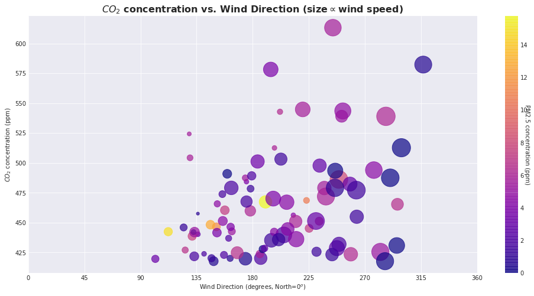

```python
plt.figure(figsize=(17, 8))
plt.scatter(
    dosenet_and_ws['WindDirection'], dosenet_and_ws['co2'],
#     dosenet_and_ws['WindDirection'], dosenet_and_ws['pgradiation'],
#     dosenet_and_ws['WindDirection'], dosenet_and_ws['pm1'],
#     dosenet_and_ws['WindDirection'], dosenet_and_ws['pm25'],
#     dosenet_and_ws['WindDirection'], dosenet_and_ws['WindSpeedMPH']
    c=dosenet_and_ws['pm25'], s=dosenet_and_ws['WindSpeedMPH']*200,
    cmap='plasma', alpha=0.7
)
cbar = plt.colorbar()
cbar.set_label('PM2.5 concentration (ppm)', rotation=270)
plt.xlabel('Wind Direction (degrees, North=$0^o$)')
plt.ylabel('$CO_2$ concentration (ppm)')
plt.xlim(left=0, right=360)
plt.xticks([45 * i for i in range(9)])
plt.title('$CO_2$ concentration vs. Wind Direction (size$\propto$wind speed)')
plt.show()
```

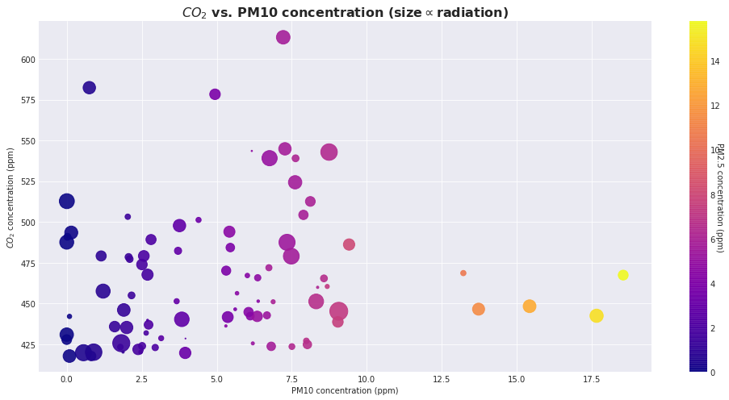

```python
plt.figure(figsize=(17, 8))
plt.scatter(
    dosenet_and_ws['pm10'], dosenet_and_ws['co2'],
#     dosenet_and_ws['WindDirection'], dosenet_and_ws['pgradiation'],
#     dosenet_and_ws['WindDirection'], dosenet_and_ws['pm1'],
#     dosenet_and_ws['WindDirection'], dosenet_and_ws['pm25'],
#     dosenet_and_ws['WindDirection'], dosenet_and_ws['WindSpeedMPH']
    c=dosenet_and_ws['pm25'],
    s=10*abs(dosenet_and_ws['radiation'] - (sum(dosenet_and_ws['radiation'])/len(dosenet_and_ws['radiation']))),
    cmap='plasma', alpha=0.9
)
cbar = plt.colorbar()
cbar.set_label('PM2.5 concentration (ppm)', rotation=270)
plt.xlabel('PM10 concentration (ppm)')
plt.ylabel('$CO_2$ concentration (ppm)')
plt.title('$CO_2$ vs. PM10 concentration (size$\propto$radiation)')
# plt.xlim(left=0, right=360)
# plt.xticks([45 * i for i in range(9)])
plt.show()
```

This plot looks similar to the one we saw at Etcheverry Hall. This is interesting. Let's make some more graphs to see what else we can dig out!

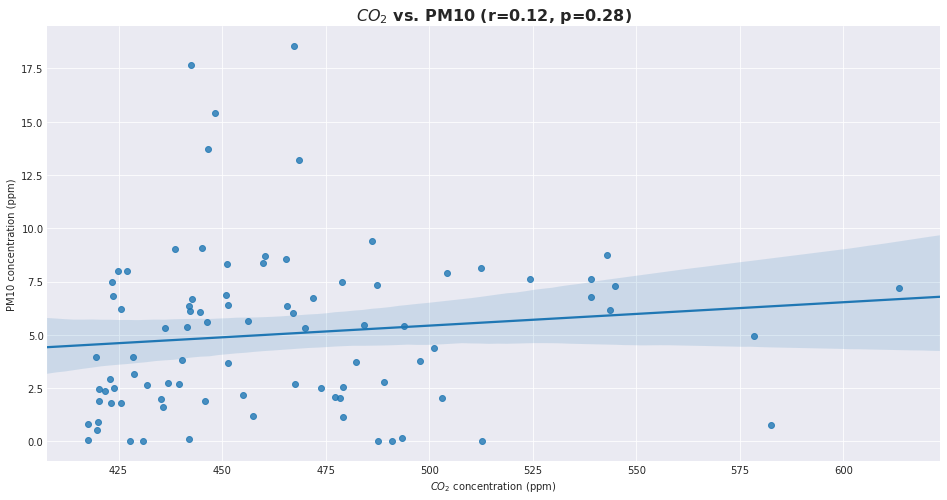

```python
f, ax = plt.subplots(figsize=(16,8))
sns.regplot('co2', 'pm10', data=dosenet_and_ws, ax=ax)
plt.xlabel('$CO_2$ concentration (ppm)')
plt.ylabel('PM10 concentration (ppm)')
r, p = pearsonr(dosenet_and_ws['co2'], dosenet_and_ws['pm10'])
plt.title(f'$CO_2$ vs. PM10 (r={r:.2f}, p={p:.2f})')
None  # otherwise matplotlib spews out a little bit of garbage
```

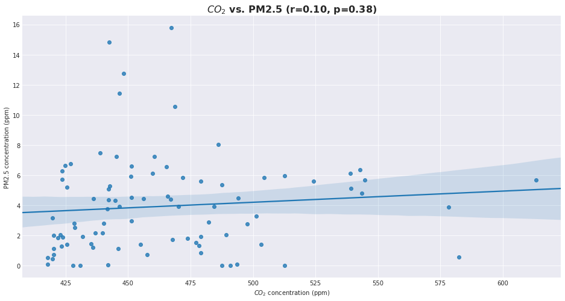

```python
f, ax = plt.subplots(figsize=(16,8))
sns.regplot('co2', 'pm25', data=dosenet_and_ws, ax=ax)
plt.xlabel('$CO_2$ concentration (ppm)')
plt.ylabel('PM2.5 concentration (ppm)')
r, p = pearsonr(dosenet_and_ws['co2'], dosenet_and_ws['pm25'])
plt.title(f'$CO_2$ vs. PM2.5 (r={r:.2f}, p={p:.2f})')
None  # otherwise matplotlib spews out a little bit of garbage
```

Very interestingly, the correlation between $CO_2$ concentration and particulate matter is positive at Pinewood! This is unlike Etcheverry Hall, where the correlation was negative. However, the data points are all over the place, so this finding has a very high p-value, implying low statistical significance (there is $28\%$ (PM10) and $38\%$ (PM2.5) probability that the results are due to random chance alone). Let's do a sanity check and see if the particulate matter levels are correlated with each other.

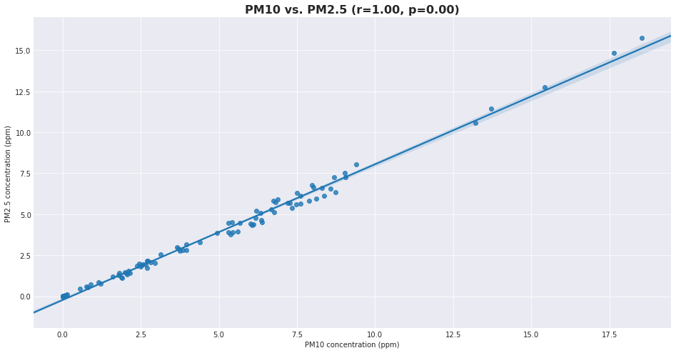

```python
f, ax = plt.subplots(figsize=(16,8))
sns.regplot('pm10', 'pm25', data=dosenet_and_ws, ax=ax)
plt.xlabel('PM10 concentration (ppm)')
plt.ylabel('PM2.5 concentration (ppm)')
r, p = pearsonr(dosenet_and_ws['pm10'], dosenet_and_ws['pm25'])
plt.title(f'PM10 vs. PM2.5 (r={r:.2f}, p={p:.2f})')
None
```

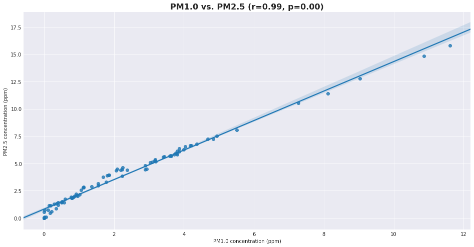

```python
f, ax = plt.subplots(figsize=(16,8))
sns.regplot('pm1', 'pm25', data=dosenet_and_ws, ax=ax)
plt.xlabel('PM1.0 concentration (ppm)')
plt.ylabel('PM2.5 concentration (ppm)')
r, p = pearsonr(dosenet_and_ws['pm1'], dosenet_and_ws['pm25'])
plt.title(f'PM1.0 vs. PM2.5 (r={r:.2f}, p={p:.2f})')
None
```

Indeed, the particulate matter readings are highly correlated with a very high level of statistical significance. I seem to see something interesting in the last regression plot. I think a residual plot might tell us something.

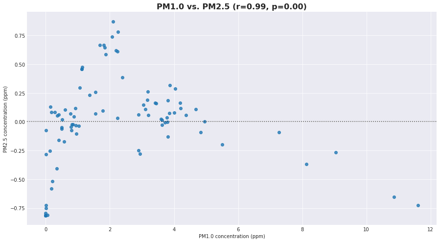

```python
f, ax = plt.subplots(figsize=(15,8))
sns.residplot('pm1', 'pm25', data=dosenet_and_ws, ax=ax)
plt.xlabel('PM1.0 concentration (ppm)')
plt.ylabel('PM2.5 concentration (ppm)')
r, p = pearsonr(dosenet_and_ws['pm1'], dosenet_and_ws['pm25'])
plt.title(f'PM1.0 vs. PM2.5 (r={r:.2f}, p={p:.2f})')
None
```

Clearly, there is a nonlinear relationship between PM1.0 and PM2.5 concentrations. Let's see if that is also the case between PM2.5 and PM10 (which will also automatically tell us about the relationship between PM1.0 and PM10 as well).

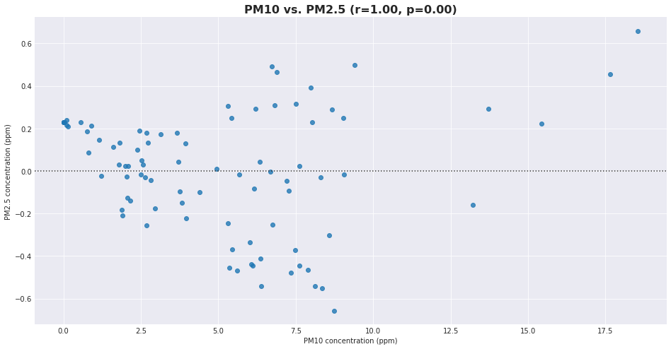

```python
f, ax = plt.subplots(figsize=(16,8))
sns.residplot('pm10', 'pm25', data=dosenet_and_ws, ax=ax)
plt.xlabel('PM10 concentration (ppm)')
plt.ylabel('PM2.5 concentration (ppm)')
r, p = pearsonr(dosenet_and_ws['pm10'], dosenet_and_ws['pm25'])
plt.title(f'PM10 vs. PM2.5 (r={r:.2f}, p={p:.2f})')
None
```